# Deploying a Shiny App on AWS

Ian Kloo

ian.p.kloo.civ@mail.mil

## Introduction

This tutorial will show you how to take a shiny app and host it on an AWS instance running shiny server. The material presented here is going to borrow from many existing tutorials in an attempt to bring everything together in one place.

This tutorial assumes that you are able to make a Shiny App and are ready to deploy it so that people can use it. I will use the “Hello Shiny” app that is included with shiny to make things simple.

The basic framework for deploying an app is pretty simple:

1. Write an app that works locally
2. Set up shiny server on an AWS instance
3. Deploy your app on shiny server

While this sounds simple, I ran into a lot of obstacles along the way, so I wanted to document the steps that I took to successfully deploy an app.

## Write an app that works locally

I will not go into this step - there are a lot of good tutorials describing how to use shiny. If you want to follow along without a pre-built app, you can use the “Hello Shiny” app (which is what I will use). You can run that using:

```r
library(shiny)
runExample("01_hello")
```

## Set up shiny server on an AWS instance

### Materials List

Before we get started, here are the things you will need to be able to pull off this methodology:

1. Access to an AWS account (with the ability to stand up a new instance)
2. A completed, running (locally) shiny app
3. A terminal with an ssh client

You may not know if you have the last item on the list. Linux and Mac OS come pre-packaged with ssh clients, but (unfortunately) Windows does not. Fortunately, Git comes with an ssh client and a terminal. I recommend going to the Git website and using the Git Bash terminal for this project (that’s what I’ll use).

### Step 1: Start an AWS Instance running R Studio

While you don’t actually need R Studio to run shiny server, I strongly recommend you include R Studio in your installation in order to make testing/troubleshooting easier. Also, it is nice to have a coding environment set up “in the cloud.”

I recommend you use the R Studio AMI (amazon machine image) here: http://www.louisaslett.com/RStudio_AMI/.

If you are not familiar with AMIs, they are simply pre-built instances that you can use to help reduce the workload of setting up an AWS instance. The AMI I recommend is built on Linux (Ubuntu) and includes R Studio out of the box.

Once you click on the AMI region that you want to use, you will be asked to sign in to AWS. After you sign in, set up the instance like this:

**1a. Select your instance type**

It doesn’t really matter what you pick because you can always change your instance type later (if you need more speed). Lets go with the free t2.micro instance to start.

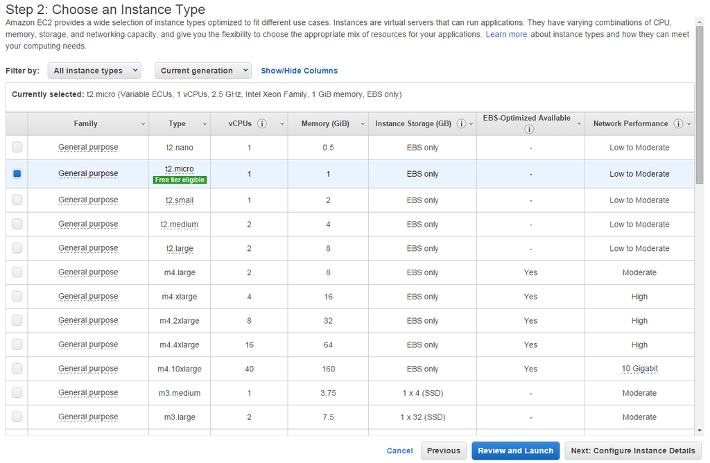

**1b. Click through the next few screens, selecting whatever you prefer - the defaults are fine.**

**1c. Configure your security group to look like this:**

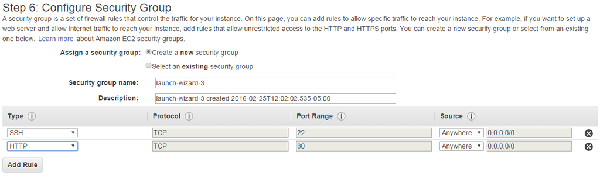

The key is to make sure you have SSH open on port 22 and HTTP open on port 80. You can further restrict the IP ranges that have access to your server, but this is not an easy thing to do on government networks (your outgoing IP is hard to find and can represent an entire post/installation…not exactly “secure”). We will address security in a bit - for now, lets assume it is OK for your empty instance to be available to the public (if they know the web address).

**1d. Click “Review and Launch” and then “Launch” on the next page.**

**1e. Select a key pair**

You will be prompted to set up a key pair. Either use an existing one, or let Amazon make one up for you. Keep in mind, you will not be able to ssh into your instance without the key, so consider storing it somewhere safe from hard drive failures, etc.

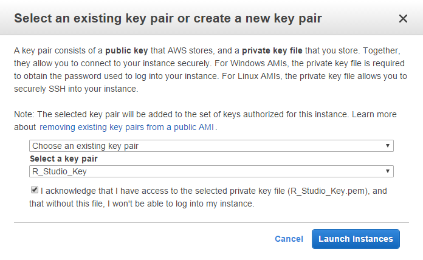

**1f. Go to the “Instances” section of your console**

Wait for your newly created instance to change status to “running.” You may also have to wait until “Status Checks” reads “2/2 checks.”

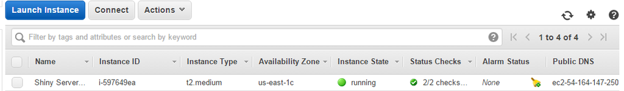

Test out your work by copying the Public DNS (looks something like this: ec2-52-90-57-214.compute-1.amazonaws.com) and pasting in your web browser. The default username and password are both “rstudio.”

### Step 2: Install Shiny Server on your Instance

The AMI we used already includes a lot of great stuff, but it doesn’t include shiny server. If we want to host our shiny apps so they can be accessed by visiting a url, we need to first set up shiny server.

This section mirrors the tutorial found here: https://www.digitalocean.com/community/tutorials/how-to-set-up-shiny-server-on-ubuntu-14-04. I will emphasize different things, so feel free to check out the original tutorial for a different take.

**2a. SSH into your instance**

If you don’t know what this means: you will be connecting to the command line of your server through the command line on your computer.

If you’re using Git Bash, open up a console and navigate to the folder where your key pair was saved during the instance setup process. If you don’t know much about linux, all you need to know is the “cd” command (change directory) is how you move to new directories. For example, if I saved my key to the Downloads folder, I would write:

```
cd Downloads
```

To get the command you need to enter next, right click on your instance in the console and click “connect.” You will get something like this:

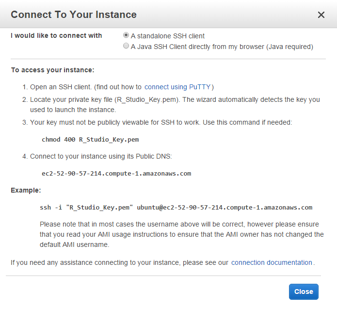

The code under “Example” is what you want to use. So I would write in my Git Bash console:

```
ssh -i "R_Studio_Key.pem" ubuntu@ec2-52-90-57-214.compute-1.amazonaws.com
```

If all goes well, you will see something like this:

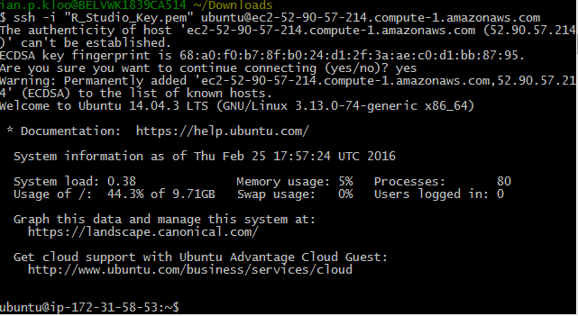

Note that it says &quot;ubuntu@ip-…" at the bottom - this is how you know you are connected via SSH.

It is a good idea to run this command as soon as you login to make sure everything is up to date:

```
sudo apt-get update
```

**2b. Install Shiny**

You already have R installed, but the Shiny package isn’t yet installed. Even if you installed Shiny in your R Studio instance, you still need to reinstall shiny from the console so it can be accessed system wide.

```
sudo su - -c "R -e \"install.packages('shiny', repos='http://cran.rstudio.com/')\""
```

**2c. Install Shiny Server**

```
sudo apt-get install gdebi-core

wget -O shiny-server.deb http://download3.rstudio.org/ubuntu-12.04/x86_64/shiny-server-1.3.0.403-amd64.deb

sudo gdebi shiny-server.deb
```

If everything worked, your shiny server will be broadcasting out of port 3838 (by default). You may be able to see the shiny test page by going to: http://YourServerPublicDNS:3838/, but many government networks block this port. We will work around this in the next section.

**2d. Set up a reverse proxy server**

To set up your shiny server to actually work on a government network, you need to set up a reverse proxy server. In basic terms, we will set up a server that will listen on port 80 (which we are allowed to hit on government networks) and route traffic to the appropriate place. Put differently, we will set up a system that make it look like both R Studio and shiny server are being hosted on port 80 to avoid getting blocked by the firewall.

We will use Nginx to set up the reverse proxy.

```
sudo apt-get install nginx
```

If your install went as planned, you will see a “Welcome to nginx” page when you try to navigate to your public DNS in your browser (below). If you are not seeing this page, but you think the install went well, try starting/restarting nginx and rebooting your instance (from the AWS management console).

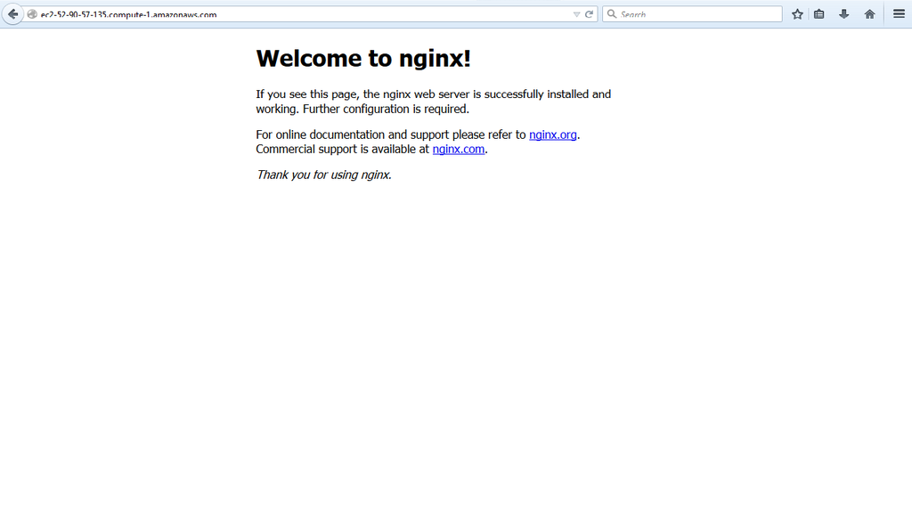

Now we need to edit the Nginx configuration to do what we want. You can open the configuration file by typing this in the terminal:

```
sudo vim /etc/nginx/sites-enabled/default
```

Note, if you don’t know how to use “vim” to edit files, just do some quick google searching.

Find the section that starts with:

```
server_name localhost;
```

and these two statements:

```
location /shiny/ {
  proxy_pass http://127.0.0.1:3838/;
}

location /rstudio/ {
  proxy_pass http://127.0.0.1:8787/;
}
```

After saving the file,

```
sudo service nginx start
```

If everything is working right, you can get to the “Welcome to Shiny Server” page at: YourPublicDNS/shiny/.

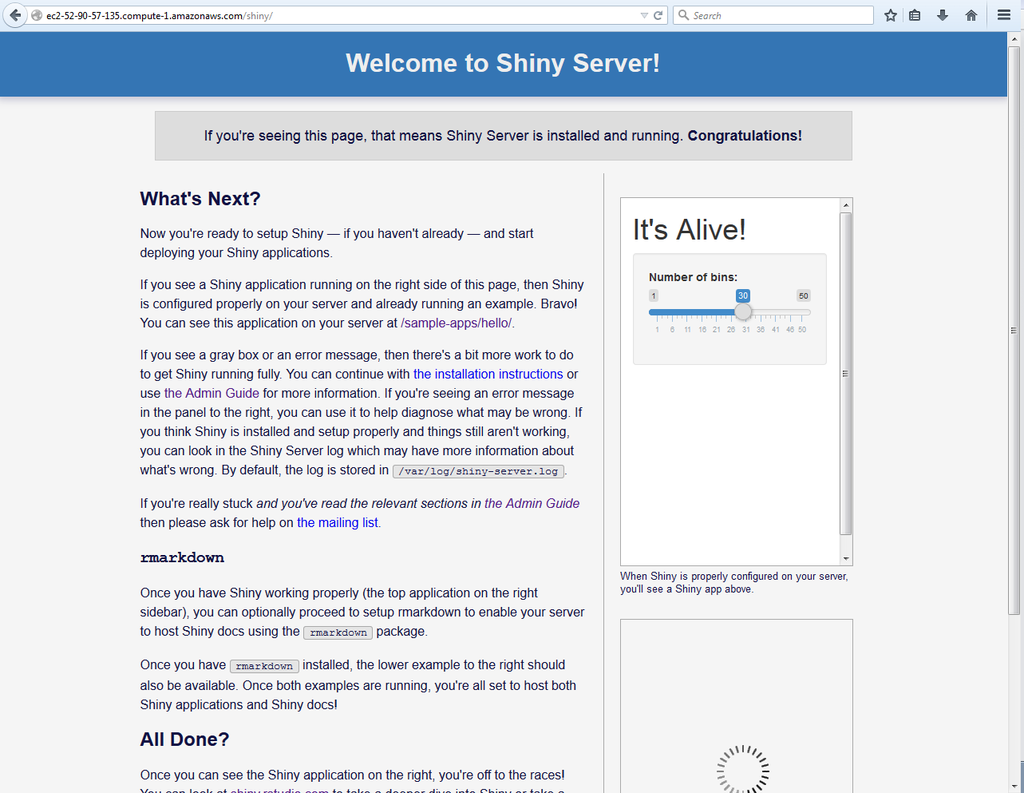

You can also get back to your R Studio page at YourPublicDNS/rstudio/.

If you are unable to access your R Studio page or the shiny server page, take an additional step. The AMI we are using is already set up so that R Studio is broadcast on port 80, which may be causing the nginx server to get confused (not a technical explanation…). To fix this, we just need to remove one line from a file:

```
sudo vim /etc/rstudio/rserver.conf
```

Hopefully, you will see a single line of code in this file:

```
www-port=80
```

As you could probably guess, this is making R Studio broadcast on port 80 instead of 8787. Delete this line and save the file. Then reset both rstudio server and Nginx:

```
sudo rstudio-server restart
sudo service nginx restart
```

### 3. Add Password Protection

Before putting up anything that you wouldn’t want the whole world to see, you should password protect your server. I’ll show how to do this with Apache Utils.

**3a. SSH into your instance.**

**3b. Install Apache Utils**

```
sudo apt-get install apache2-utils
```

**3c. Create username and password**

```
sudo htpasswd -c /etc/nginx/.htpasswd InsertUserNameHere
```

You will then be asked to enter a password twice.

**3d. Add user/password to Nginx configuration**

Open up the config file for Nginx (sites available):

```
sudo vim /etc/nginx/sites-available/default
```

Add these two lines under the locations you want to have password protected:

```
auth_basic "Restricted";
auth_basic_user_file /etc/nginx/.htpasswd;
```

For example, if you want to have just the shiny server under password protection, your file should look like:

```
...
location /rstudio/ {

proxy_pass http://127.0.0.1:87/;

}

location /shiny/ {

proxy_pass http://127.0.0.1:3838/;
auth_basic "Restricted";
auth_basic_user_file /etc/nginx/.htpasswd;
}
```

Now, just reload the Nginx configuration:

```
sudo /etc/init.d/nginx reload
```

You will now be asked for a username and password when you login to the shiny server. Note, you can also place the login restrictions on the rstudio instance (or the whole site), but since R Studio already has a password enabled, I’ll skip this.

### 4. Install Packages

In order for shiny server to run your app, you may need to install packages. This is not quite as easy as it usually is with R: you can’t just install the packages in Rstudio.

The solution is to install packages directly in the shiny server:

**4a. SSH into your instance (as described above).**

**4b. Switch from the “ubuntu” user to the “shiny” user:**

```
sudo su - shiny
```

**4c. Open R as the shiny user.**

```
R
```

Packages installed using this method will be available to the shiny app.

### 5. Deploy a Shiny App

Finally!

Fortunately, it isn’t too hard to add a shiny app to the server.

You can actually run a test app right now. Just navigate to: YOURDOMAIN/shiny to get to the Shiny Server welcome page and click the “/sample-apps/hello/” link.

**4a. Prep app**

To upload a new app to the server, first make sure that your app is separated into two files: ui.r and server.r. Here are the test files we’ll use:

ui.R

```r
library(shiny)

# Define UI for application that draws a histogram
shinyUI(fluidPage(

  # Application title
  titlePanel("Hello Shiny!"),

  # Sidebar with a slider input for the number of bins
  sidebarLayout(
    sidebarPanel(
      sliderInput("bins",
                  "Number of bins:",
                  min = 1,
                  max = 50,
                  value = 30)
    ),

    # Show a plot of the generated distribution
    mainPanel(
      plotOutput("distPlot")
    )
  )
))
```

server.R

```r
library(shiny)

# Define server logic required to draw a histogram
shinyServer(function(input, output) {

  # Expression that generates a histogram. The expression is
  # wrapped in a call to renderPlot to indicate that:
  #
  #  1) It is "reactive" and therefore should re-execute automatically
  #     when inputs change
  #  2) Its output type is a plot

  output$distPlot <- renderPlot({
    x    <- faithful[, 2]  # Old Faithful Geyser data
    bins <- seq(min(x), max(x), length.out = input$bins + 1)

    # draw the histogram with the specified number of bins
    hist(x, breaks = bins, col = 'darkgray', border = 'white')
  })
})
```

Make sure you can run the app locally before you try to set it up on your AWS instance. Troubleshooting is much easier on your local machine.

Your app should be a single folder with the ui and server files (also any data, pictures, etc.) inside. A basic framework (the one we’ll use here) that uses no data should look like:

-Demo App –ui.r –server.r

**4b. Load app on your server**

In order for shiny server to host your app, you need to save it in the folder located at: /srv/shiny-server.

The trick is moving the files from your local machine to the AWS instance. If you have some software (like FileZilla) that you like to use to move files, go ahead and use it. If you have no idea what I’m talking about, use SCP (secure copy) to move files from the command line.

With a command line on your local machine (*not one that is ssh’ed into your AWS instance), the command looks like this:

```
scp -i LocationOfYourKey -r LocationOfYourLocalFile LocationWhereYouWantToMoveIt
```

In my case, the command looks like:

```
scp -i R_Studio_Key.pem -r ~/Desktop/DemoApp ubuntu@ec2-52-90-57-135.compute-1.amazonaws.com:~/DemoApp
```

This will copy the entire local directory DemoApp to a new folder called DemoApp that is created in the root directory of your AWS instance. It would be more efficient just to move the folder right into /srv/shiny-server, but I have run into a lot of permissions problems trying to do this. I recommend moving the files/folder into the root directory, then ssh’ing into the instance to move the files to the correct server folder.

Now, we can move the files into the shiny server folder (after ssh’ing into the instance):

```
sudo mv DemoApp /srv/shiny-server/DemoApp
```

**4c. Test app**

If everything was done right, you should now be able to visit your app by navigating to: YOURDOMAIN/shiny/NAMEOFYOURAPP.

In my case: http://ec2-52-90-57-135.compute-1.amazonaws.com/shiny/DemoApp/

*Make sure that you include /shiny/ before the name of your app!!!! Web browsers tend to drop this for some reason, so make sure you re-enter /shiny if it is dropped (otherwise you will get a server error).

## Conclusion

Now you should have an shiny app that is running on an AWS instance! Consider making a custom AMI to save your setup. This will save you some time next time you want to deploy an app (on a different instance).

This tutorial showed one interesting way to use AWS, but there are many other interesting use cases. I will continue to document my AWS learning - please consider making a tutorial if you find an interesting, repeatable use case for AWS.